# Análise exploratória do Dataset "House Prices - Advanced Regression Techniques"

## 1 Introdução

## 2 Coleta de Dados

```python
# Importando as bibliotecas necessárias


#Para cálculos e dataframe
import pandas as pd
import numpy as np

#Para criação de gráficos
%matplotlib inline
import matplotlib.pyplot as plt
import seaborn as sns

#Para amostragem dos dados de treino e teste
from sklearn.model_selection import train_test_split

#Para substituir os valores ausentes
from sklearn.impute import SimpleImputer

#para transformar variáveis categóricas em numéricas
from sklearn.preprocessing import OneHotEncoder

#Para normalizar os dados

from sklearn.preprocessing import StandardScaler

#PAra criar pipelines
from sklearn.pipeline import Pipeline

#Para criar pipelines de pré-processamento

from sklearn.compose import ColumnTransformer

#Para normalizar os dados

from sklearn.preprocessing import StandardScaler

from sklearn.model_selection import cross_val_score
```

```python
# Algumas configurações iniciais

pd.set_option('display.max_columns',81)
```

# 3 Aquisição de dados

```python
# Carregando os dados de treino

train = pd.read_csv('/content/drive/MyDrive/Colab Notebooks/Projetos/Advanced Houses/train.csv')

# Exibindo o dataset

train
```

|  | Id | MSSubClass | MSZoning | LotFrontage | LotArea | Street | Alley | LotShape | LandContour | Utilities | LotConfig | LandSlope | Neighborhood | Condition1 | Condition2 | BldgType | HouseStyle | OverallQual | OverallCond | YearBuilt | YearRemodAdd | RoofStyle | RoofMatl | Exterior1st | Exterior2nd | MasVnrType | MasVnrArea | ExterQual | ExterCond | … |
| --- | --- | --- | --- | --- | --- | --- | --- | --- | --- | --- | --- | --- | --- | --- | --- | --- | --- | --- | --- | --- | --- | --- | --- | --- | --- | --- | --- | --- | --- | --- |
| 0 | 1 | 60 | RL | 65.0 | 8450 | Pave | NaN | Reg | Lvl | AllPub | Inside | Gtl | CollgCr | Norm | Norm | 1Fam | 2Story | 7 | 5 | 2003 | 2003 | Gable | CompShg | VinylSd | VinylSd | BrkFace | 196.0 | Gd | TA | … |
| 1 | 2 | 20 | RL | 80.0 | 9600 | Pave | NaN | Reg | Lvl | AllPub | FR2 | Gtl | Veenker | Feedr | Norm | 1Fam | 1Story | 6 | 8 | 1976 | 1976 | Gable | CompShg | MetalSd | MetalSd | None | 0.0 | TA | TA | … |
| 2 | 3 | 60 | RL | 68.0 | 11250 | Pave | NaN | IR1 | Lvl | AllPub | Inside | Gtl | CollgCr | Norm | Norm | 1Fam | 2Story | 7 | 5 | 2001 | 2002 | Gable | CompShg | VinylSd | VinylSd | BrkFace | 162.0 | Gd | TA | … |
| 3 | 4 | 70 | RL | 60.0 | 9550 | Pave | NaN | IR1 | Lvl | AllPub | Corner | Gtl | Crawfor | Norm | Norm | 1Fam | 2Story | 7 | 5 | 1915 | 1970 | Gable | CompShg | Wd Sdng | Wd Shng | None | 0.0 | TA | TA | … |
| 4 | 5 | 60 | RL | 84.0 | 14260 | Pave | NaN | IR1 | Lvl | AllPub | FR2 | Gtl | NoRidge | Norm | Norm | 1Fam | 2Story | 8 | 5 | 2000 | 2000 | Gable | CompShg | VinylSd | VinylSd | BrkFace | 350.0 | Gd | TA | … |
| ... | ... | ... | ... | ... | ... | ... | ... | ... | ... | ... | ... | ... | ... | ... | ... | ... | ... | ... | ... | ... | ... | ... | ... | ... | ... | ... | ... | ... | ... | … |
| 1455 | 1456 | 60 | RL | 62.0 | 7917 | Pave | NaN | Reg | Lvl | AllPub | Inside | Gtl | Gilbert | Norm | Norm | 1Fam | 2Story | 6 | 5 | 1999 | 2000 | Gable | CompShg | VinylSd | VinylSd | None | 0.0 | TA | TA | … |
| 1456 | 1457 | 20 | RL | 85.0 | 13175 | Pave | NaN | Reg | Lvl | AllPub | Inside | Gtl | NWAmes | Norm | Norm | 1Fam | 1Story | 6 | 6 | 1978 | 1988 | Gable | CompShg | Plywood | Plywood | Stone | 119.0 | TA | TA | … |
| 1457 | 1458 | 70 | RL | 66.0 | 9042 | Pave | NaN | Reg | Lvl | AllPub | Inside | Gtl | Crawfor | Norm | Norm | 1Fam | 2Story | 7 | 9 | 1941 | 2006 | Gable | CompShg | CemntBd | CmentBd | None | 0.0 | Ex | Gd | … |
| 1458 | 1459 | 20 | RL | 68.0 | 9717 | Pave | NaN | Reg | Lvl | AllPub | Inside | Gtl | NAmes | Norm | Norm | 1Fam | 1Story | 5 | 6 | 1950 | 1996 | Hip | CompShg | MetalSd | MetalSd | None | 0.0 | TA | TA | … |
| 1459 | 1460 | 20 | RL | 75.0 | 9937 | Pave | NaN | Reg | Lvl | AllPub | Inside | Gtl | Edwards | Norm | Norm | 1Fam | 1Story | 5 | 6 | 1965 | 1965 | Gable | CompShg | HdBoard | HdBoard | None | 0.0 | Gd | TA | … |

1460 rows × 81 columns

Nosso conjunto de dados apresenta 1460 linhas e 81 colunas, que é um número bastante alto de *features*.

# 4 Análise Exploratória dos Dados

## 4.1 Separação entre duas variáveis: categóricas e numéricas

Nesse projeto, precisamos primeiramente entender que tipo de dados temos em cada coluna. Como vimos, o dataset contém 81 colunas. Vejamos quais os tipos de cada uma:

```python
pd.DataFrame(train.dtypes, columns = ['Type']).T
```

|  | Id | MSSubClass | MSZoning | LotFrontage | LotArea | Street | Alley | LotShape | LandContour | Utilities | LotConfig | LandSlope | Neighborhood | Condition1 | Condition2 | BldgType | HouseStyle | OverallQual | OverallCond | YearBuilt | YearRemodAdd | RoofStyle | RoofMatl | Exterior1st | Exterior2nd | MasVnrType | MasVnrArea | ExterQual | ExterCond | … |
| --- | --- | --- | --- | --- | --- | --- | --- | --- | --- | --- | --- | --- | --- | --- | --- | --- | --- | --- | --- | --- | --- | --- | --- | --- | --- | --- | --- | --- | --- | --- |
| Type | int64 | int64 | object | float64 | int64 | object | object | object | object | object | object | object | object | object | object | object | object | int64 | int64 | int64 | int64 | object | object | object | object | object | float64 | object | object | … |

As colunas são dos tipos 'object', 'int64' ou 'float64'.  
Para facilitar as análises, vamos separar as colunas, primeiramente, em dois tipos:

- variáveis categóricas: 'object'
- variáveis numéricas: 'float64' e 'int64'.

Mais a frente, analisaremos se as variáveis do tipo 'int64' podem ser, na verdade, categóricas.

```python
var_cat =[]
var_num =[]

for col in train.drop(columns=['Id','SalePrice']).columns:
  if train[col].dtypes == object:
    var_cat.append(col)
  else:
    var_num.append(col)
print(f"Há {len(var_cat)} variáveis categóricas ('object'): \n {var_cat}\n")
print(f"Há {len(var_num)} varáveis numéricas ('int64 e float 64'): \n {var_num}")
```

```
Há 43 variáveis categóricas ('object'):
 ['MSZoning', 'Street', 'Alley', 'LotShape', 'LandContour', 'Utilities', 'LotConfig', 'LandSlope', 'Neighborhood', 'Condition1', 'Condition2', 'BldgType', 'HouseStyle', 'RoofStyle', 'RoofMatl', 'Exterior1st', 'Exterior2nd', 'MasVnrType', 'ExterQual', 'ExterCond', 'Foundation', 'BsmtQual', 'BsmtCond'…

Há 36 varáveis numéricas ('int64 e float 64'):
 ['MSSubClass', 'LotFrontage', 'LotArea', 'OverallQual', 'OverallCond', 'YearBuilt', 'YearRemodAdd', 'MasVnrArea', 'BsmtFinSF1', 'BsmtFinSF2', 'BsmtUnfSF', 'TotalBsmtSF', '1stFlrSF', '2ndFlrSF', 'LowQualFinSF', 'GrLivArea', 'BsmtFullBath', 'BsmtHalfBath', 'FullBath', 'HalfBath', 'BedroomAbvGr', 'Kit…
```

## 4.2 Descrição dos dados

Vamos agora verificar que tipo de informações podemos obter sobre cada tipo de dado contidas nas colunas.

Primeiramente para as variáveis categóricas:

### 4.2.1 Variáveis categóricas

```python
train[var_cat].describe()
```

|  | MSZoning | Street | Alley | LotShape | LandContour | Utilities | LotConfig | LandSlope | Neighborhood | Condition1 | Condition2 | BldgType | HouseStyle | RoofStyle | RoofMatl | Exterior1st | Exterior2nd | MasVnrType | ExterQual | ExterCond | Foundation | BsmtQual | BsmtCond | BsmtExposure | BsmtFinType1 | BsmtFinType2 | Heating | HeatingQC | CentralAir | … |
| --- | --- | --- | --- | --- | --- | --- | --- | --- | --- | --- | --- | --- | --- | --- | --- | --- | --- | --- | --- | --- | --- | --- | --- | --- | --- | --- | --- | --- | --- | --- |
| count | 1460 | 1460 | 91 | 1460 | 1460 | 1460 | 1460 | 1460 | 1460 | 1460 | 1460 | 1460 | 1460 | 1460 | 1460 | 1460 | 1460 | 1452 | 1460 | 1460 | 1460 | 1423 | 1423 | 1422 | 1423 | 1422 | 1460 | 1460 | 1460 | … |
| unique | 5 | 2 | 2 | 4 | 4 | 2 | 5 | 3 | 25 | 9 | 8 | 5 | 8 | 6 | 8 | 15 | 16 | 4 | 4 | 5 | 6 | 4 | 4 | 4 | 6 | 6 | 6 | 5 | 2 | … |
| top | RL | Pave | Grvl | Reg | Lvl | AllPub | Inside | Gtl | NAmes | Norm | Norm | 1Fam | 1Story | Gable | CompShg | VinylSd | VinylSd | None | TA | TA | PConc | TA | TA | No | Unf | Unf | GasA | Ex | Y | … |
| freq | 1151 | 1454 | 50 | 925 | 1311 | 1459 | 1052 | 1382 | 225 | 1260 | 1445 | 1220 | 726 | 1141 | 1434 | 515 | 504 | 864 | 906 | 1282 | 647 | 649 | 1311 | 953 | 430 | 1256 | 1428 | 741 | 1365 | … |

Podemos verificar que há algumas variáveis variáveis que apresentam apenas dois tipos de valores. São elas:

**Street**: Tipo de acesso rodoviário  
**Alley**: Tipo de acesso ao beco  
**Utilities**: Tipo de utilitários disponíveis  
**CentralAir**: Ar condicionado central

No entanto, quando consultamos a descrição do problema, verificamos que as colunas 'Alley' e 'Utilities' apresentam 3 e 4 valores possíveis, respectivamente. Vamos armazená-las em uma nova lista::

```python
var_bin = ['Street','Alley','Utilities','CentralAir']
```

Outras colunas apresentam valores únicos variando de 3 a 25:

\ **MSZoning**: Identifica a classificação geral do zoneamento da venda  
**LotShape**: Forma geral da propriedade  
**LandContour**: Planicidade da propriedade  
**LotConfig**: Configuração do lote  
**LandSlope**: Declive da propriedade  
**Neighborhood**: Locais físicos dentro dos limites da cidade  
**Condition1**: Proximidade de várias condições  
**Condition2**: Proximidade de várias condições (se mais de uma estiver presente)  
**BldgType**: Tipo de habitação  
**HouseStyle**: Estilo de habitação  
**RoofStyle**: Tipo de telhado  
**RoofMatl**: Material do telhado  
**Exterior1st**: Revestimento exterior da casa  
**Exterior2nd**: Revestimento externo da casa (se houver mais de um material)  
**MasVnrType**: Tipo folheado de alvenaria  
**ExterQual**: Avalia a qualidade do material no exterior  
**ExterCond**: Avalia a condição atual do material no exterior  
**Foundation**: Tipo de fundação  
**BsmtQual**: Avalia a altura do porão  
**BsmtCond**: Avalia o estado geral da cave  
**BsmtExposure**: Refere-se a paralisações ou paredes no nível do jardim  
**BsmtFinType1**: Classificação da área finalizada do porão  
**BsmtFinType2**: Classificação da área finalizada do porão (se vários tipos)  
**Heating**: Tipo de aquecimento  
**HeatingQC**: Qualidade e condição do aquecimento  
**Electrical**: Sistema elétrico  
**KitchenQual**: Qualidade da cozinha  
**Functional**: Funcionalidade doméstica  
**FireplaceQu**: Qualidade de lareira  
**GarageType**: Localização da garagem  
**GarageFinish**: Acabamento interior da garagem  
**GarageQual**: Qualidade de garagem  
**GarageCond**: Condição de garagem  
**PavedDrive**: Estrada pavimentada  
**PoolQC**: Qualidade da piscina  
**Fence**: Qualidade da cerca  
**MiscFeature**: Diversos recursos não cobertos em outras categorias  
**SaleType**: Tipo de venda  
**SaleCondition**: Condição de venda

Algumas das variáveis categóricas acima, claramente apresentam uma relação **ordinal** ou de **ranking** entre seus valores. São elas:

| Coluna | Valores |
| --- | --- |
| ExterQual | Ex/Gd/TA/Fa/Po/ |
| ExterCond | Ex/Gd/TA/Fa/Po/ |
| BsmtQual | Ex/Gd/TA/Fa/Po/ |
| BsmtCond | Ex/Gd/TA/Fa/Po/NA |
| BsmtExposure | Gd/TA/Mn/No/NA |
| BsmtFinType1 | GLQ/ALQ/BLQ/Rec/LwQ/Unf/NA |
| BsmtFinType2 | GLQ/ALQ/BLQ/Rec/LwQ/Unf/NA |
| BsmtCond | Ex/Gd/Av/Fa/Po/NA |
| HeatingQC | Ex/Gd/Av/Fa/Po/ |
| KitchenQual | Ex/Gd/Av/Fa/Po/ |
| FireplaceQu | Ex/Gd/Av/Fa/Po/NA |
| GarageQual | Ex/Gd/Av/Fa/Po/NA |
| GarageCond | Ex/Gd/Av/Fa/Po/NA |
| PoolQC | Ex/Gd/TA/Fa/No |

Legendas:

```
   Ex   Excellent (Excelente)
   Gd   Good (Bom)
   TA   Typical (Típico)
   Fa   Fair (Justo)
   Po   Poor (Pobre)
   Av   Average (Médio)
   NA/No    Nonexistent (Não existe)
   Mn   Minimum (Mínimo)
   GLQ  Good Living Quarters (Bons Alojamentos)
   ALQ  Average Living Quarters (Alojamentos razoáveis)
   BLQ  Below Average Living Quarters   (Alojamentos abaixo da média)
   Rec  Average Rec Room (Quarto médio)
   LwQ  Low Quality (Baixa Qualidade)
   Unf  Unfinshed (Inacabado)
```

Vamos guardar tais variáveis em uma lista:

```python
var_rank = ['ExterQual','ExterCond','BsmtQual','BsmtCond','BsmtExposure','BsmtFinType1','BsmtFinType2','HeatingQC','KitchenQual','FireplaceQu','GarageQual','GarageCond','PoolQC']
```

### 4.2.2 Variáveis numéricas

Analisaremos agora as variáveis numéricas:

Descrição das variáveis numéricas:

**MSSubClass:** Identifica o tipo de habitação envolvido na venda  
**LotFrontage**: pés lineares de rua conectados à propriedade  
**LotArea:** Tamanho do lote em pés quadrados  
**OverallQual:** Classifica o material geral e o acabamento da casa  
**OverallCond:** Classifica a condição geral da casa  
**YearBuilt:** data de construção original  
**YearRemodAdd:** Data de remodelação (igual à data de construção se não houver remodelação ou acréscimos)  
**MasVnrArea:** Área de folheado de alvenaria em pés quadrados  
**BsmtFinSF1:** Tipo 1 pés quadrados acabados  
**BsmtFinSF2:** Tipo 2 pés quadrados acabados  
**BsmtUnfSF:** pés quadrados inacabados da área do porão  
**TotalBsmtSF:** pés quadrados totais da área do porão  
**1stFlrSF:** pés quadrados do primeiro andar  
**2ndFlrSF:** pés quadrados do segundo andar  
**LowQualFinSF:** pés quadrados acabados de baixa qualidade (todos os andares)  
**GrLivArea:** Área habitável acima do solo (pés quadrados)  
**BsmtFullBath:** Banheiros completos no porão  
**BsmtHalfBath:** lavabos no porão  
**FullBath:** Banheiros completos acima do nível do solo  
**HalfBath:** Meios banhos acima do grau  
**BedroomAbvGr:** Número de quartos acima do subsolo  
**KitchenAbvGr:** Cozinhas acima do nível  
**TotRmsAbvGrd:** Total de quartos acima do nível (não inclui banheiros)  
**Lareiras:** Número de lareiras  
**GarageYrBlt:** ano em que a garagem foi construída  
**GarageCars:** Tamanho da garagem na capacidade do carro  
**GarageArea:** Tamanho da garagem em pés quadrados  
**WoodDeckSF:** Área de deck de madeira em pés quadrados  
**OpenPorchSF:** Área de varanda aberta em pés quadrados  
**EnclosedPorch:** Área da varanda fechada em pés quadrados  
**3SsnPorch:** Área de varanda de três estações em pés quadrados  
**ScreenPorch:** Área da varanda de tela em pés quadrados  
**PoolArea:** Área da piscina em metros quadrados  
**MiscVal:** $Valor do recurso diverso  
**MoSold:** Mês Vendido (MM)  
**YrSold:** Ano de venda (AAAA)

```python
train[var_num].describe()
```

|  | MSSubClass | LotFrontage | LotArea | OverallQual | OverallCond | YearBuilt | YearRemodAdd | MasVnrArea | BsmtFinSF1 | BsmtFinSF2 | BsmtUnfSF | TotalBsmtSF | 1stFlrSF | 2ndFlrSF | LowQualFinSF | GrLivArea | BsmtFullBath | BsmtHalfBath | FullBath | HalfBath | BedroomAbvGr | KitchenAbvGr | TotRmsAbvGrd | Fireplaces | GarageYrBlt | GarageCars | GarageArea | WoodDeckSF | OpenPorchSF | … |
| --- | --- | --- | --- | --- | --- | --- | --- | --- | --- | --- | --- | --- | --- | --- | --- | --- | --- | --- | --- | --- | --- | --- | --- | --- | --- | --- | --- | --- | --- | --- |
| count | 1460.000000 | 1201.000000 | 1460.000000 | 1460.000000 | 1460.000000 | 1460.000000 | 1460.000000 | 1452.000000 | 1460.000000 | 1460.000000 | 1460.000000 | 1460.000000 | 1460.000000 | 1460.000000 | 1460.000000 | 1460.000000 | 1460.000000 | 1460.000000 | 1460.000000 | 1460.000000 | 1460.000000 | 1460.000000 | 1460.000000 | 1460.000000 | 1379.000000 | 1460.000000 | 1460.000000 | 1460.000000 | 1460.000000 | … |
| mean | 56.897260 | 70.049958 | 10516.828082 | 6.099315 | 5.575342 | 1971.267808 | 1984.865753 | 103.685262 | 443.639726 | 46.549315 | 567.240411 | 1057.429452 | 1162.626712 | 346.992466 | 5.844521 | 1515.463699 | 0.425342 | 0.057534 | 1.565068 | 0.382877 | 2.866438 | 1.046575 | 6.517808 | 0.613014 | 1978.506164 | 1.767123 | 472.980137 | 94.244521 | 46.660274 | … |
| std | 42.300571 | 24.284752 | 9981.264932 | 1.382997 | 1.112799 | 30.202904 | 20.645407 | 181.066207 | 456.098091 | 161.319273 | 441.866955 | 438.705324 | 386.587738 | 436.528436 | 48.623081 | 525.480383 | 0.518911 | 0.238753 | 0.550916 | 0.502885 | 0.815778 | 0.220338 | 1.625393 | 0.644666 | 24.689725 | 0.747315 | 213.804841 | 125.338794 | 66.256028 | … |
| min | 20.000000 | 21.000000 | 1300.000000 | 1.000000 | 1.000000 | 1872.000000 | 1950.000000 | 0.000000 | 0.000000 | 0.000000 | 0.000000 | 0.000000 | 334.000000 | 0.000000 | 0.000000 | 334.000000 | 0.000000 | 0.000000 | 0.000000 | 0.000000 | 0.000000 | 0.000000 | 2.000000 | 0.000000 | 1900.000000 | 0.000000 | 0.000000 | 0.000000 | 0.000000 | … |
| 25% | 20.000000 | 59.000000 | 7553.500000 | 5.000000 | 5.000000 | 1954.000000 | 1967.000000 | 0.000000 | 0.000000 | 0.000000 | 223.000000 | 795.750000 | 882.000000 | 0.000000 | 0.000000 | 1129.500000 | 0.000000 | 0.000000 | 1.000000 | 0.000000 | 2.000000 | 1.000000 | 5.000000 | 0.000000 | 1961.000000 | 1.000000 | 334.500000 | 0.000000 | 0.000000 | … |
| 50% | 50.000000 | 69.000000 | 9478.500000 | 6.000000 | 5.000000 | 1973.000000 | 1994.000000 | 0.000000 | 383.500000 | 0.000000 | 477.500000 | 991.500000 | 1087.000000 | 0.000000 | 0.000000 | 1464.000000 | 0.000000 | 0.000000 | 2.000000 | 0.000000 | 3.000000 | 1.000000 | 6.000000 | 1.000000 | 1980.000000 | 2.000000 | 480.000000 | 0.000000 | 25.000000 | … |
| 75% | 70.000000 | 80.000000 | 11601.500000 | 7.000000 | 6.000000 | 2000.000000 | 2004.000000 | 166.000000 | 712.250000 | 0.000000 | 808.000000 | 1298.250000 | 1391.250000 | 728.000000 | 0.000000 | 1776.750000 | 1.000000 | 0.000000 | 2.000000 | 1.000000 | 3.000000 | 1.000000 | 7.000000 | 1.000000 | 2002.000000 | 2.000000 | 576.000000 | 168.000000 | 68.000000 | … |
| max | 190.000000 | 313.000000 | 215245.000000 | 10.000000 | 9.000000 | 2010.000000 | 2010.000000 | 1600.000000 | 5644.000000 | 1474.000000 | 2336.000000 | 6110.000000 | 4692.000000 | 2065.000000 | 572.000000 | 5642.000000 | 3.000000 | 2.000000 | 3.000000 | 2.000000 | 8.000000 | 3.000000 | 14.000000 | 3.000000 | 2010.000000 | 4.000000 | 1418.000000 | 857.000000 | 547.000000 | … |

De acordo com as descrições das variáveis numéricas, vemos que as colunas 'OverallQual' e 'OverallCond' também possuem caráter de **ranking**, pois atribuem uma nota à qualidade geral do material e à condição geral da casa, respectivamente, possuindo os seguintes valores:

```
   10   Very Excellent (Muito excelente)
   9    Excellent (Excelente)
   8    Very Good (Muito bom)
   7    Good (Bom)
   6    Above Average (Acima da média)
   5    Average (Médio)
   4    Below Average (Abaixo da média)
   3    Fair (Justo)
   2    Poor (Pobre)
   1    Very Poor (Muito pobre)
```

Assim, vamos colocar essas duas variáveis também na lista 'var_rank':

```python
var_rank.append('OverallQual')
var_rank.append('OverallCond')
```

Uma vez que, algumas variáveis categóricas e numéricas foram redefinidas como binárias ou de ranking, vamos redefinir também as listas de variáveis categóricas e numéricas:

```python
for var in (var_rank+var_bin):
  if var in var_cat:
    var_cat.remove(var)

for var in var_rank:
  if var in var_num:
    var_num.remove(var)
```

[output not shown]

## 4.3 Valores ausentes

Verificaremos agora a quantidade de valores nulos presentes em cada coluna:

```python
miss_value=pd.DataFrame(columns=['Coluna', '%Ausente'])

for index,col in enumerate(train.columns):

  value = (train[col].isna().sum()/train.shape[0])*100

  if value>0:

    nova_linha=pd.DataFrame([[col,value]], columns=['Coluna', '%Ausente'], index=[index])

    miss_value = pd.concat([miss_value,nova_linha])

miss_value.sort_values(by='%Ausente', ascending=False).T
```

|  | 72 | 74 | 6 | 73 | 57 | 3 | 58 | 59 | 60 | 63 | 64 | 32 | 35 | 33 | 31 | 30 | 26 | 25 | 42 |
| --- | --- | --- | --- | --- | --- | --- | --- | --- | --- | --- | --- | --- | --- | --- | --- | --- | --- | --- | --- |
| Coluna | PoolQC | MiscFeature | Alley | Fence | FireplaceQu | LotFrontage | GarageType | GarageYrBlt | GarageFinish | GarageQual | GarageCond | BsmtExposure | BsmtFinType2 | BsmtFinType1 | BsmtCond | BsmtQual | MasVnrArea | MasVnrType | Electrical |
| %Ausente | 99.520548 | 96.30137 | 93.767123 | 80.753425 | 47.260274 | 17.739726 | 5.547945 | 5.547945 | 5.547945 | 5.547945 | 5.547945 | 2.60274 | 2.60274 | 2.534247 | 2.534247 | 2.534247 | 0.547945 | 0.547945 | 0.068493 |

Vericamos que as colunas PoolQC, MiscFeature, Alley, Fence e FireplaceQu possuem alta porcentagem de valores ausentes, que nos impede de tirar conclusões mais precisas.

## 4.4 Visualização dos dados

Vamos agora visualizar a distribuição de algumas colunas, de forma a obter alguns insights.

### 4.4.1 Distribuição da variável target

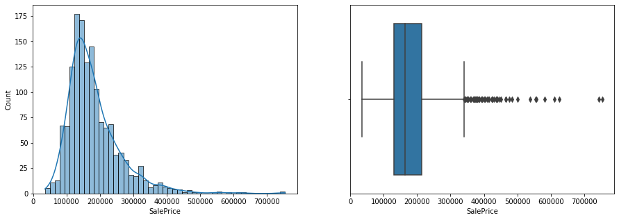

```python
fig, ax = plt.subplots(1,2,figsize=(15,5))
sns.histplot(train['SalePrice'],kde=True, ax=ax[0])
sns.boxplot(x=train['SalePrice'],ax=ax[1])
plt.show()
```

### 4.4.2 Distribuição das variáveis binárias

Vamos analisar de que forma as variáveis binárias se relacionam com os preços das casas:

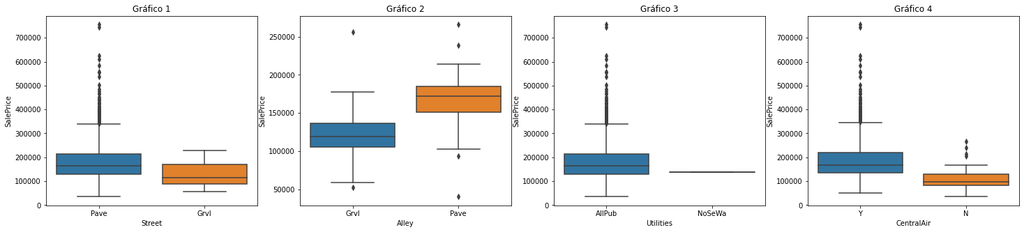

```python
plt.figure(figsize=(25,5))
for i,col in enumerate(train[var_bin],1):
  plt.subplot(1,4,i)
  sns.boxplot(data=train, x= col, y='SalePrice').set_title(f"Gráfico {i}")
```

A partir do **Gráfico 1**, é possível observar que as casas situadas em ruas não pavimentadas (Grvl) possuem valor médio e valor máximo inferior às casas em ruas pavimentadas.

No **Gráfico 2**, embora a variável 'Alley' não seja binária, pois apresenta 3 possibilidades (Grvl, Pave e NO), no dataset há apenas as os dois primeiros tipos de valores, onde podemos novamente constatar que o tipo de acesso à rua 'pavimentada' (Pave) tem valor médio e valor máximo maiores do que quando a rua não é pavimentada.

No **Gráfico 3**, novamente vemos que a variável 'Utilities' pode apresentar 4 tipos de valores, mas apresenta apensa 2.

Finalmente no Gráfico 4, relativo à presença ou não de central de ar condicionado, fica evidente que as casas que apresental ar condicionado possuem valor maior do que as casas que não apresentam.

### 4.4.3 Distribuição das variáveis ordinais ou de ranking

Como já abordado anteriormente, as variáveis ordinais são aquelas que podem apresentar comportamento no qual há uma relação entre os valores. No caso estudado aqui, as variáveis *'ExterQual', 'ExterCond', 'BsmtQual', 'BsmtCond', 'BsmtExposure', 'BsmtFinType1', 'BsmtFinType2', 'HeatingQC', 'KitchenQual', 'FireplaceQu', 'GarageQual', 'GarageCond', 'PoolQC', 'OverallQual', 'OverallCond'* apresentam um comportamento de **ranking**, onde os valores são como notas atribuídas ao quesito descrito na coluna.

Dessa forma, vamos analisar o comportamento da variável target em relação a cada uma delas. Para isso, primeiramente vamos substituir os valores categóricos contidos em cada coluna, por valores numéricos, onde 0 é a menor nota na escala.

```python
df = train.copy()

df[['ExterQual','ExterCond','HeatingQC','KitchenQual','PoolQC']] = df[['ExterQual','ExterCond','HeatingQC','KitchenQual','PoolQC']].replace(to_replace=['Ex','Gd','TA','Fa','Po'], value=[4,3,2,1,0])
df[['BsmtQual','BsmtCond','FireplaceQu','GarageQual','GarageCond']] = df[['BsmtQual','BsmtCond','FireplaceQu','GarageQual','GarageCond']].replace(to_replace=['Ex','Gd','TA','Fa','Po','NA'], value=[5,4,3,2,1,0])
df[['BsmtExposure']] = df[['BsmtExposure']].replace(to_replace=['Gd','Av','Mn','No','NA'], value=[4,3,2,1,0])
df[['BsmtFinType1','BsmtFinType2']] = df[['BsmtFinType1','BsmtFinType2']].replace(to_replace=['GLQ','ALQ','BLQ','Rec','LwQ','Unf','NA'], value=[6,5,4,3,2,1,0])

df[var_rank]
```

|  | ExterQual | ExterCond | BsmtQual | BsmtCond | BsmtExposure | BsmtFinType1 | BsmtFinType2 | HeatingQC | KitchenQual | FireplaceQu | GarageQual | GarageCond | PoolQC | OverallQual | OverallCond |
| --- | --- | --- | --- | --- | --- | --- | --- | --- | --- | --- | --- | --- | --- | --- | --- |
| 0 | 3 | 2 | 4.0 | 3.0 | 1.0 | 6.0 | 1.0 | 4 | 3 | NaN | 3.0 | 3.0 | NaN | 7 | 5 |
| 1 | 2 | 2 | 4.0 | 3.0 | 4.0 | 5.0 | 1.0 | 4 | 2 | 3.0 | 3.0 | 3.0 | NaN | 6 | 8 |
| 2 | 3 | 2 | 4.0 | 3.0 | 2.0 | 6.0 | 1.0 | 4 | 3 | 3.0 | 3.0 | 3.0 | NaN | 7 | 5 |
| 3 | 2 | 2 | 3.0 | 4.0 | 1.0 | 5.0 | 1.0 | 3 | 3 | 4.0 | 3.0 | 3.0 | NaN | 7 | 5 |
| 4 | 3 | 2 | 4.0 | 3.0 | 3.0 | 6.0 | 1.0 | 4 | 3 | 3.0 | 3.0 | 3.0 | NaN | 8 | 5 |
| ... | ... | ... | ... | ... | ... | ... | ... | ... | ... | ... | ... | ... | ... | ... | ... |
| 1455 | 2 | 2 | 4.0 | 3.0 | 1.0 | 1.0 | 1.0 | 4 | 2 | 3.0 | 3.0 | 3.0 | NaN | 6 | 5 |
| 1456 | 2 | 2 | 4.0 | 3.0 | 1.0 | 5.0 | 3.0 | 2 | 2 | 3.0 | 3.0 | 3.0 | NaN | 6 | 6 |
| 1457 | 4 | 3 | 3.0 | 4.0 | 1.0 | 6.0 | 1.0 | 4 | 3 | 4.0 | 3.0 | 3.0 | NaN | 7 | 9 |
| 1458 | 2 | 2 | 3.0 | 3.0 | 2.0 | 6.0 | 3.0 | 3 | 3 | NaN | 3.0 | 3.0 | NaN | 5 | 6 |
| 1459 | 3 | 2 | 3.0 | 3.0 | 1.0 | 4.0 | 2.0 | 3 | 2 | NaN | 3.0 | 3.0 | NaN | 5 | 6 |

1460 rows × 15 columns

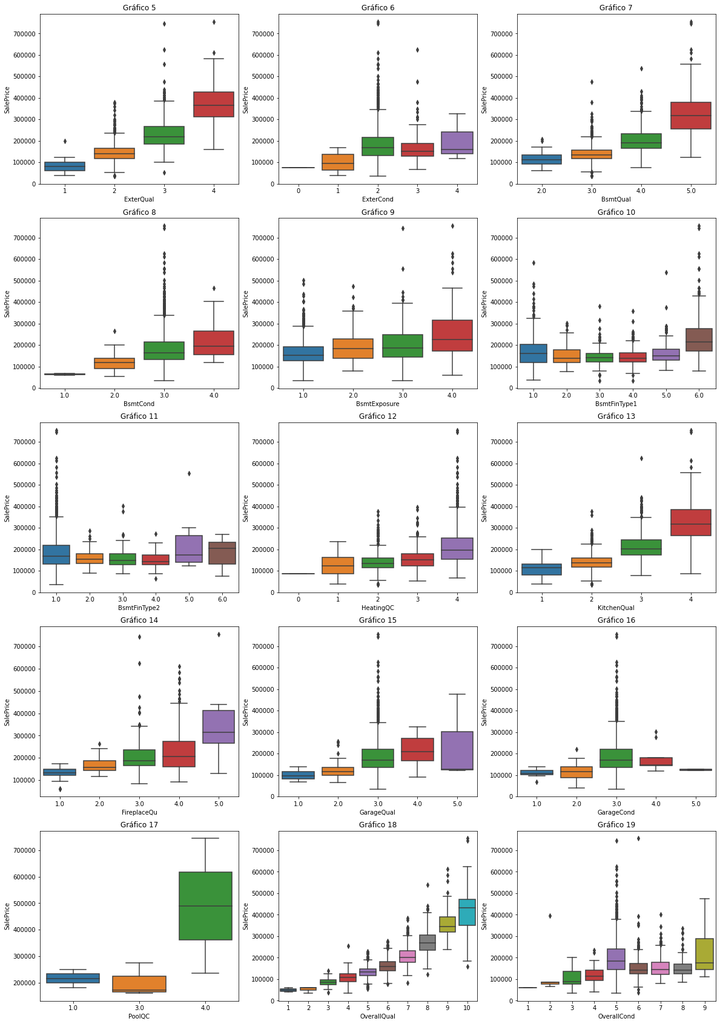

```python
plt.figure(figsize=(20,30))
for i,col in enumerate(df[var_rank],1):
  plt.subplot(5,3,i)
  sns.boxplot(data=df, x= col, y='SalePrice').set_title(f'Gráfico {i+4}')
```

### 4.4.4 Distribuição das variáveis categóricas

Agora analisaremos as variáveis categóricas:

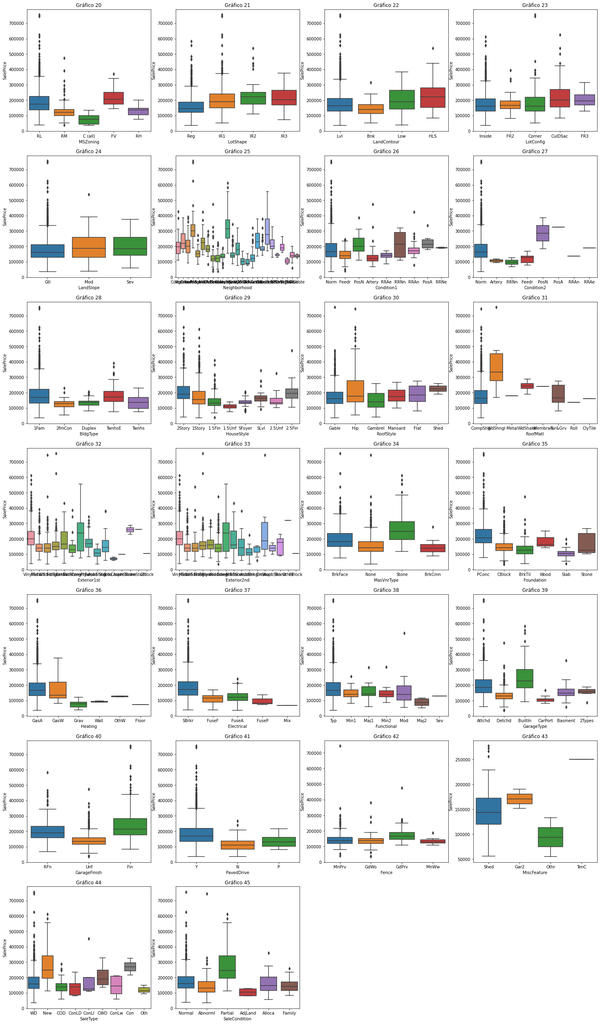

```python
plt.figure(figsize=(25,45))
for i,col in enumerate(train[var_cat],1):
  plt.subplot(7,4,i)
  sns.boxplot(data=train, x= col,y='SalePrice').set_title(f'Gráfico {i+19}')
```

[figure not shown]

```python
plt.figure(figsize=(20,20))

plt.subplot(3,1,1)
sns.boxplot(data=train, x='Neighborhood', y='SalePrice').set_title(f'Gráfico 25')

plt.subplot(3,1,2)
sns.boxplot(data=train, x='Exterior1st', y='SalePrice').set_title(f'Gráfico 32')

plt.subplot(3,1,3)
sns.boxplot(data=train, x='Exterior2nd', y='SalePrice').set_title(f'Gráfico 36')

plt.show()
```

### 4.4.5 Distribuição das Variáveis numéricas

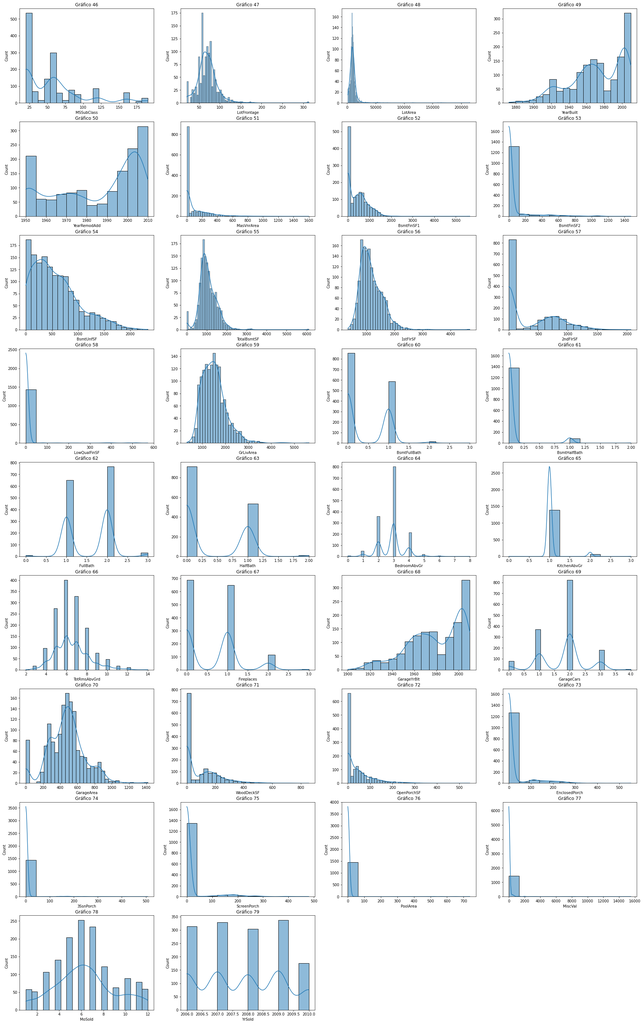

```python
plt.figure(figsize=(30,50))
for i, col in enumerate(train[var_num].columns,1):
  plt.subplot(9,4,i)
  sns.histplot(train[col],kde=True).set_title(f'Gráfico {i+45}')
```

## 4.4 Variância

Um fator importante a ser observado antes dos processos de modelagem, pode ser a variância de cada feature. Como a quantidade de atributos é bastante alta, procuraremos analisá-las a fim de encontrar variáveis **constantes** ou **quasi-constantes**, isto é, variáveis que apresentam variância nula ou muito baixa, e que terão pouca influência sobre a modelagem.

É importante que seja feita a normalização dos dados para que seja realizada uma comparação justa, pois a variância depende também da escala em que os valores se encontram. Para isso, optaremos pordividir cada coluna pela sua média, para garantir que todas estejam na mesma escala:

```python
mean = df[var_num].mean()
df[var_num] = df[var_num]/mean
```

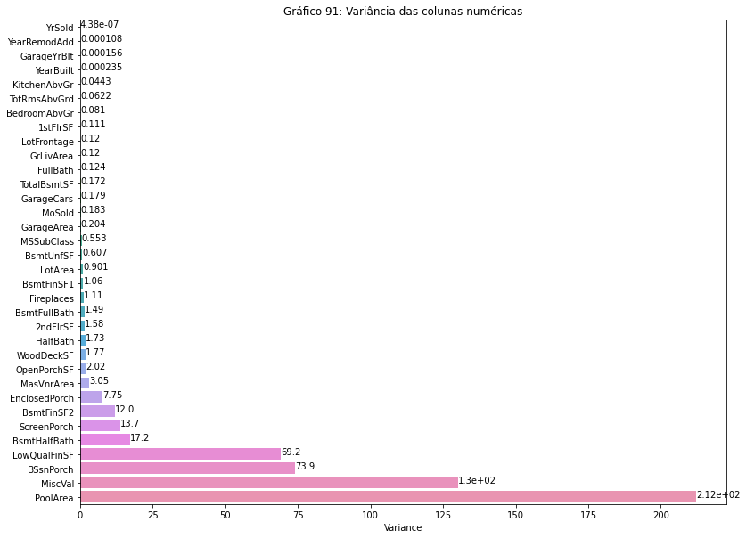

```python
variance = pd.DataFrame(df[var_num].var().sort_values(), columns=['Variance'])

fig, ax = plt.subplots(figsize=(13,10))
ax = sns.barplot(y=variance.index,x=variance['Variance'])
ax.set_title(f'Gráfico 91: Variância das colunas numéricas')

for index, value in enumerate (variance['Variance']):
  plt.text(value, index, f'{value:.3}')

plt.show()
```

Podemos verificar que as variâncias vão da ordem de 10^-7 até 10^2, e há muitas features com baixa variância, que teriam sua remoção estudada em casos de modelagem.

```python
train[['PoolArea','MiscVal','3SsnPorch','LowQualFinSF','BsmtHalfBath','ScreenPorch','BsmtFinSF2','EnclosedPorch','MasVnrArea','OpenPorchSF','WoodDeckSF','HalfBath','2ndFlrSF','BsmtFullBath','Fireplaces']].describe()
```

|  | PoolArea | MiscVal | 3SsnPorch | LowQualFinSF | BsmtHalfBath | ScreenPorch | BsmtFinSF2 | EnclosedPorch | MasVnrArea | OpenPorchSF | WoodDeckSF | HalfBath | 2ndFlrSF | BsmtFullBath | Fireplaces |
| --- | --- | --- | --- | --- | --- | --- | --- | --- | --- | --- | --- | --- | --- | --- | --- |
| count | 1460.000000 | 1460.000000 | 1460.000000 | 1460.000000 | 1460.000000 | 1460.000000 | 1460.000000 | 1460.000000 | 1452.000000 | 1460.000000 | 1460.000000 | 1460.000000 | 1460.000000 | 1460.000000 | 1460.000000 |
| mean | 2.758904 | 43.489041 | 3.409589 | 5.844521 | 0.057534 | 15.060959 | 46.549315 | 21.954110 | 103.685262 | 46.660274 | 94.244521 | 0.382877 | 346.992466 | 0.425342 | 0.613014 |
| std | 40.177307 | 496.123024 | 29.317331 | 48.623081 | 0.238753 | 55.757415 | 161.319273 | 61.119149 | 181.066207 | 66.256028 | 125.338794 | 0.502885 | 436.528436 | 0.518911 | 0.644666 |
| min | 0.000000 | 0.000000 | 0.000000 | 0.000000 | 0.000000 | 0.000000 | 0.000000 | 0.000000 | 0.000000 | 0.000000 | 0.000000 | 0.000000 | 0.000000 | 0.000000 | 0.000000 |
| 25% | 0.000000 | 0.000000 | 0.000000 | 0.000000 | 0.000000 | 0.000000 | 0.000000 | 0.000000 | 0.000000 | 0.000000 | 0.000000 | 0.000000 | 0.000000 | 0.000000 | 0.000000 |
| 50% | 0.000000 | 0.000000 | 0.000000 | 0.000000 | 0.000000 | 0.000000 | 0.000000 | 0.000000 | 0.000000 | 25.000000 | 0.000000 | 0.000000 | 0.000000 | 0.000000 | 1.000000 |
| 75% | 0.000000 | 0.000000 | 0.000000 | 0.000000 | 0.000000 | 0.000000 | 0.000000 | 0.000000 | 166.000000 | 68.000000 | 168.000000 | 1.000000 | 728.000000 | 1.000000 | 1.000000 |
| max | 738.000000 | 15500.000000 | 508.000000 | 572.000000 | 2.000000 | 480.000000 | 1474.000000 | 552.000000 | 1600.000000 | 547.000000 | 857.000000 | 2.000000 | 2065.000000 | 3.000000 | 3.000000 |

## 4.5 Correlação

Nesta etapa, procuraremos visualizar as possíveis correlações entre as variáveis numéricas e ordinais com a vaariável target, e também entre elas mesmas.  
Para isso, utilizaremos os métodos relacionados à correlação linear de Pearson.

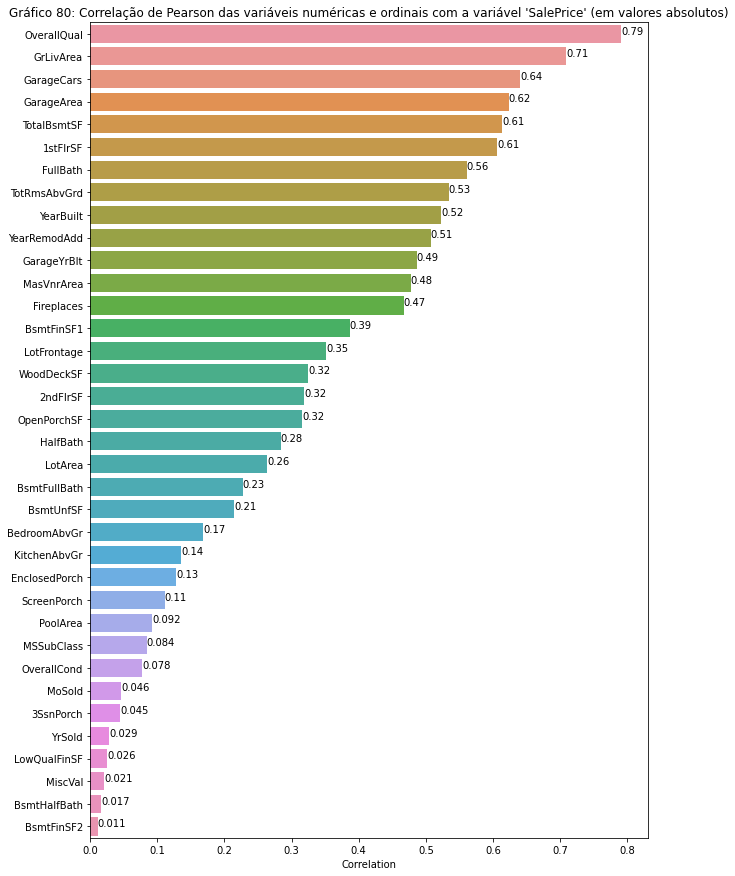

```python
plt.figure(figsize=(10,15))

corr = pd.DataFrame(train[['SalePrice']+var_num+var_rank].corr()['SalePrice'].abs().sort_values(ascending = False)).drop(index=['SalePrice'])
corr.columns = ['Correlation']

bar = sns.barplot(y = corr.index, x=corr['Correlation']).set_title("Gráfico 80: Correlação de Pearson das variáveis numéricas e ordinais com a variável 'SalePrice' (em valores absolutos)")

for index, value in enumerate (corr['Correlation']):
  plt.text(value, index, f'{value:.2}')

plt.show()
```

Observamos que as colunas 'OverallQual', 'GrLivArea', 'GarageCars','GarageArea', 'TotalBsmtSF', 'FullBath', 'TotRmsAbvGrd', 'YearBuilt' apresentam alta correlação linear com a variável 'SalePrice'.

**Tais colunas se referem-se às condições, tamanho, quantidade de cômodos e ano de construção dos imóveis, fatores já esperados como influência sobre os preços.**

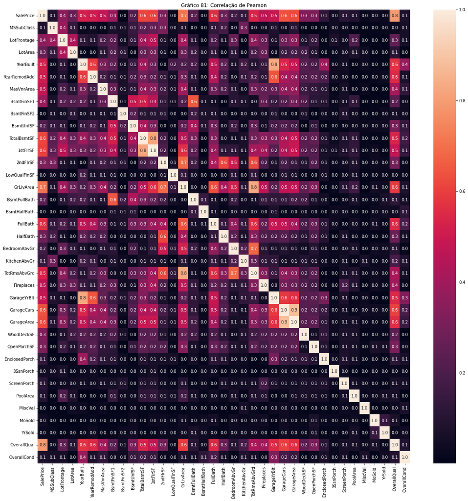

```python
plt.figure(figsize=(20,20))
ax = sns.heatmap(train[['SalePrice']+var_num+var_rank].corr().abs(), annot = True, fmt=".1f")
ax.set_title('Gráfico 81: Correlação de Pearson')
plt.show()
```

Podemos ainda destacar outras relações entre as variáveis:

- **'TotalBsmtSF' x '1stFlrSF':** Área do porão e Área do 1º andar.

Essa relação é esperada e quase redundante, uma vez que a área do 1º andar corresponde, na maioria das vezes, à área do porão.

- **'YearBuilt'x'GarageYrBlt':** Ano de construção do imóvel e ano de construção da garagem.

Aqui a correlação é quase que óbvia, uma vez que na maioria das vezes a garagem do imóvel é construída simultaneamente ao imóvel.

- **'GarageCars' x 'GarageArea':** Quantidade de vagas de carro na garagem e Área da garagem.

Mais uma correlação esperada: quanto maior a área da garagem, maior a quantidade de vagas disponíveis.

Abaixo, vejamos de que forma a variável independente 'SalePrice' se distribui em função das 9 variáveis dependentes com maior correlação de Pearson.

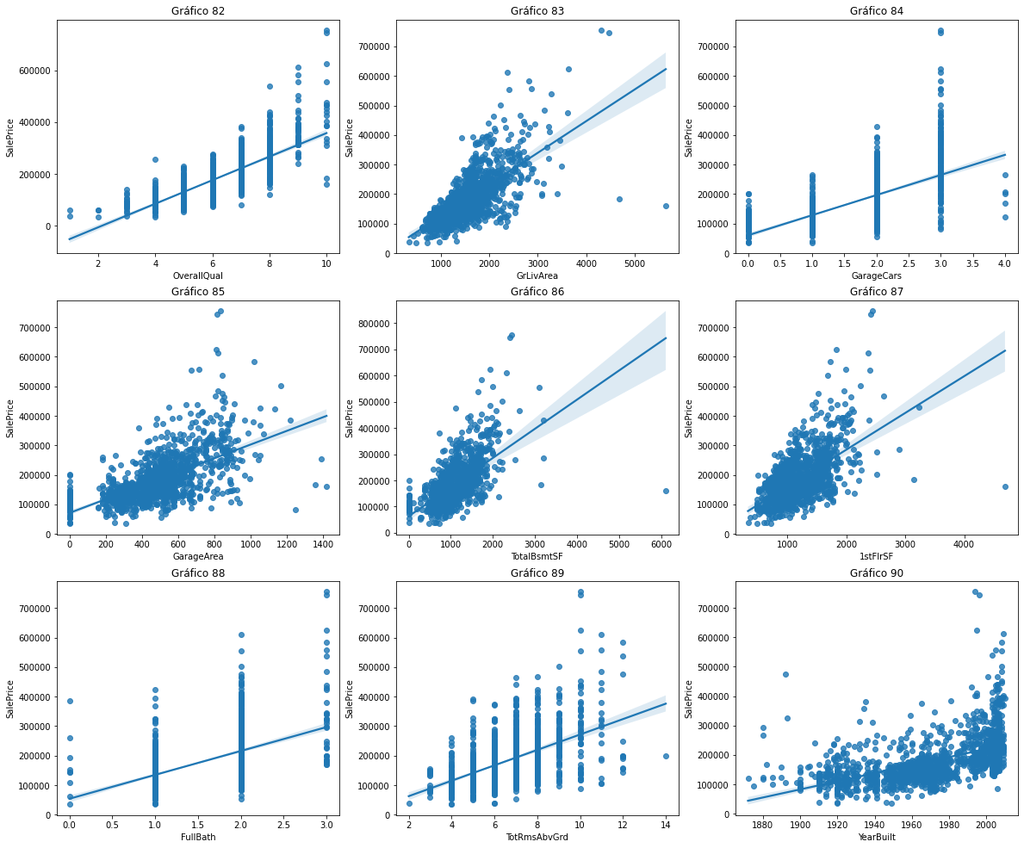

```python
plt.figure(figsize=(20,17))
for i, col in enumerate(corr.head(9).index,1):
  plt.subplot(3,3,i)
  sns.regplot(data=train, x=col, y='SalePrice').set_title(f'Gráfico {i+81}')
```

# 5 Conclusão

Neste trabalho, procurou-se realizar uma Análise Exploratória do dataset de competição do Kaggle, entitulado "House Prices - Advanced Regression Techniques".

Alguns pontos importantes: